# Composable evolution: swapping simulation features

Re-wiring the model with the operator syntax, without touching the kernel

## The idea

In `CategoricalQuantGen` one generation is a *composite of operators*:

$$\texttt{generation} = \texttt{develop} \cdot \texttt{select} \cdot
\texttt{reproduce} \cdot \texttt{mutate} \cdot \texttt{swap}.$$

Each operator is a first-class `Operator` value — a morphism on the world state. Because composition (`⋅`) and stratification (`⊗`) are just algebra on these values, you can **swap, drop, insert, duplicate, or stratify** components to change the biology *without editing the validated array kernel*. That these re-wirings are well-defined — associativity, and a run being the iterate of one composed generation — is exactly what `lean/CategoricalQuantGen/Composition.lean` proves. This vignette shows a few.

```julia
using CategoricalQuantGen
using Random, Statistics, Printf
using CairoMakie
import CategoricalQuantGen: ⋅, ⊗     # Catlab's composition/stratification, not LinearAlgebra's ⋅
CairoMakie.activate!(type = "png")

const cols = [:navy, :teal, :crimson]

# A tiny driver that runs ANY composed generation operator, recording the
# parents' phenotype mean and genotype variance each generation. `develop!` is
# deterministic (no RNG), so calling it to record does not perturb the run.
function run_variant(genop::Operator, p::Params; seed)
    rng = MersenneTwister(seed); w = World(p); esd = sqrt(envVar(p))
    for i in 1:p.PopSize; w.env[i] = esd * randn(rng); end
    gens = Int[]; pm = Float64[]; gv = Float64[]
    for it in 0:p.NoGenerations-1
        w.gen = it
        develop!(w)
        push!(gens, it); push!(pm, mean(w.phenotype)); push!(gv, var(w.genotype))
        genop(w, rng)                      # apply the whole (custom) generation
        w.extinct && break
    end
    (gen = gens, pheno_mean = pm, geno_var = gv, extinct = w.extinct)
end
```

## 1. Swap the *selection* operator

`select` is just one link in the chain. Replace it and the whole regime changes; `reproduce` and `mutate` are reused verbatim.

```julia
# neutral drift: everyone survives (fitness ≡ 1)
drift = Operator(:drift, function (w, rng)
    fill!(w.fitness, 1.0)
    resize!(w.survivors, w.p.PopSize); w.survivors .= 1:w.p.PopSize
    w.nsurv = w.p.PopSize
    w
end)

# directional truncation: only the top `frac` of individuals by phenotype breed
truncation(frac) = Operator(:truncation, function (w, rng)
    k = max(2, round(Int, frac * w.p.PopSize))
    top = partialsortperm(w.phenotype, 1:k; rev = true)
    resize!(w.survivors, k); w.survivors .= top; w.nsurv = k
    w
end)

base = Params(PopSize = 1000, Ploidy = 2, NoQTL = 1, NoGenerations = 2000,
              PhenotypeVar = 0.02, Heritability = 0.5,
              MutationScalar = 0.02, MutationRatePerGamete = 0.5, InitFitnessSD = 0.3)

selection_variants = [
    ("stabilizing",           develop ⋅ select           ⋅ reproduce ⋅ mutate ⋅ swap),
    ("drift (neutral)",       develop ⋅ drift            ⋅ reproduce ⋅ mutate ⋅ swap),
    ("directional (top 20%)", develop ⋅ truncation(0.2)  ⋅ reproduce ⋅ mutate ⋅ swap),
]
runs1 = [(name, run_variant(g, base; seed = 20240724)) for (name, g) in selection_variants]
```

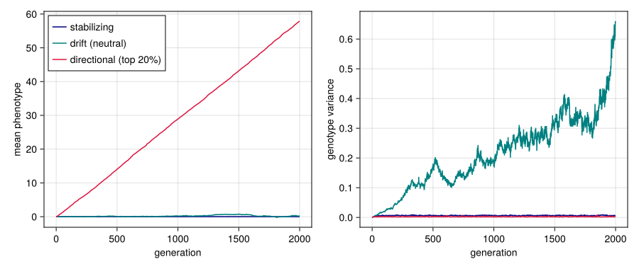

Figure 1: Swapping only the selection operator. Left: mean phenotype — stabilizing holds it at the optimum (0), drift wanders, directional truncation drives it upward. Right: genotype variance — stabilizing reaches a mutation–selection balance, drift accumulates variance, truncation erodes it.

```julia
fig = Figure(size = (900, 380))
ax1 = Axis(fig[1,1], xlabel = "generation", ylabel = "mean phenotype")
ax2 = Axis(fig[1,2], xlabel = "generation", ylabel = "genotype variance")
for (i, (name, r)) in enumerate(runs1)
    lines!(ax1, r.gen, r.pheno_mean, color = cols[i], label = name)
    lines!(ax2, r.gen, r.geno_var,   color = cols[i], label = name)
end
axislegend(ax1, position = :lt)
fig
```

Three regimes, three one-line pipelines — the kernel’s `reproduce!`/`mutate!` are shared unchanged.

## 2. Change the *mutation* input

Drop `mutate` and variance decays under selection; duplicate it (`mutate ⋅ mutate`) and the mutation–selection balance rises. Composition makes “twice the mutation” literally twice the operator.

```julia
mutation_variants = [
    ("no mutation",     develop ⋅ select ⋅ reproduce ⋅ swap),
    ("baseline",        develop ⋅ select ⋅ reproduce ⋅ mutate ⋅ swap),
    ("double mutation", develop ⋅ select ⋅ reproduce ⋅ mutate ⋅ mutate ⋅ swap),
]
runs2 = [(name, run_variant(g, base; seed = 7)) for (name, g) in mutation_variants]
```

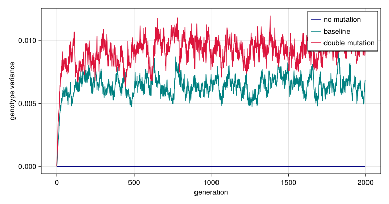

Figure 2: Swapping the mutation operator changes the equilibrium genetic variance: none → collapses toward 0, baseline → mutation–selection balance, doubled → a higher balance.

```julia
fig = Figure(size = (760, 400))
ax = Axis(fig[1,1], xlabel = "generation", ylabel = "genotype variance")
for (i, (name, r)) in enumerate(runs2)
    lines!(ax, r.gen, r.geno_var, color = cols[i], label = name)
end
axislegend(ax, position = :rt)
fig
```

## 3. Stratify with `⊗`, then couple with `migration`

`⊗` lifts the model to a metapopulation of demes; a composed generation acts on each deme pointwise, and a `migration` operator can be appended with `⋅` to couple them. Here neutral demes drift apart on their own but stay coherent once migration is composed into the generation.

```julia
function run_strat(genop::Operator, s::Stratified, ngen; seed)
    rng = MersenneTwister(seed)
    for w in s.demes, i in 1:w.p.PopSize; w.env[i] = sqrt(envVar(w.p)) * randn(rng); end
    means = [Float64[] for _ in s.demes]
    for it in 0:ngen-1
        for (di, w) in enumerate(s.demes)
            w.gen = it; develop!(w); push!(means[di], mean(w.phenotype))
        end
        genop(s, rng)
    end
    means
end

sp = Params(PopSize = 200, Ploidy = 2, NoQTL = 1, NoGenerations = 1,
            PhenotypeVar = 0.02, Heritability = 0.5,
            MutationScalar = 0.05, MutationRatePerGamete = 0.5)
gen_drift = develop ⋅ drift ⋅ reproduce ⋅ mutate ⋅ swap    # reuse the drift operator from §1

# The composed generation acts on each deme; `migration` is a metapopulation-level
# operator that couples them, appended with the same `⋅` composition.
isolated = run_strat(gen_drift,                    sp ⊗ Demes(4), 2500; seed = 1)
coupled  = run_strat(gen_drift ⋅ migration(0.05),  sp ⊗ Demes(4), 2500; seed = 1)
```

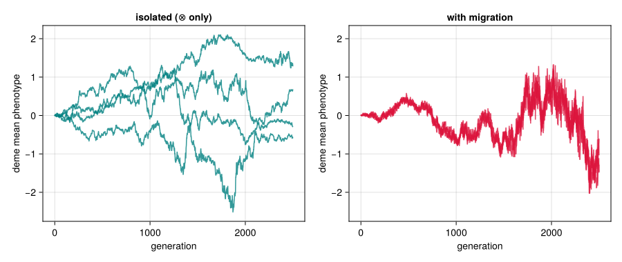

Figure 3: Four neutral demes. Left: isolated (`⊗` only) — deme means drift apart. Right: `gen_drift ⋅ migration(0.05)` — migration keeps them coherent. Same operators; the only change is composing a migration morphism into the generation.

```julia
fig = Figure(size = (900, 380))
ax1 = Axis(fig[1,1], xlabel = "generation", ylabel = "deme mean phenotype", title = "isolated (⊗ only)")
ax2 = Axis(fig[1,2], xlabel = "generation", ylabel = "deme mean phenotype", title = "with migration")
for d in 1:4
    lines!(ax1, 0:length(isolated[d])-1, isolated[d], color = (:teal, 0.8))
    lines!(ax2, 0:length(coupled[d])-1,  coupled[d],  color = (:crimson, 0.8))
end
linkyaxes!(ax1, ax2)
fig
```

## Why this works

Every variant above is a few lines of *composition*, not a fork of the simulator: the validated kernel (`develop!` / `select!` / `reproduce!` / `mutate!`) is reused verbatim, and only the wiring changes. That the wiring is meaningful — that `(f ⋅ g) ⋅ h = f ⋅ (g ⋅ h)`, and that a run is the iterate of one composed generation — is precisely what `lean/CategoricalQuantGen/Composition.lean` proves. The compositional syntax turns *“change a feature of the model”* into *“swap a morphism”* — the whole point of the AlgebraicJulia formulation, and the foundation for lowering the same abstract model to other backends (e.g. the Eidos/SLiM port in `slim_port/`).